# Going through VAS and Qolie

Astrid

2022-09-22

# Analysis and Result Briefs

## QOLIE(QOLIE-31 & QOLIE-AD-48)

### the Inclusion Criteria of QOLIE records

**Source**

1. from both Screening and Follow up visits;
2. including both QOLIE-31 and QOLIE-AD-48.

**Logic for selecting same-day QOLIE records**

For every participant, if there exists 2 QOLIE records on the same day,

1. choose the one with type(QOLIE-31/QOLIE-AD-48) more eligible for the age(11-17 use QOLIE-AD-48, >18 use QOLIE-31);
2. if the same QOLIE type, choose the one with less missing domain and less missing items;
3. if still the same, choose the one with bigger *instance*.

**Logic for i-th QOLIE**

For every participant,

1. the baseline date is obtained from *date_consent_screen* or *dataconsentenroll*, choosing one based on *ev0*;
2. 0th QOLIE(**first**): the first occurence of QOLIE records, no matter whether the date is on or before or after the baseline date, and no matter whether the record is from Screening or Follow up Visits, except from one case: the date is after “2022-01-01”;
3. 3rd QOLIE(**last**): the last time of QOLIE records and the date is after “2022-01-01”. For those who have only one time QOLIE record, if the date is after “2022-01-01”, the record will be labeled as the 3-rd, as the participants are only old enough(>11) for the last time of visits(maybe we can compare their previous VAS score and this time of QOLIE);
4. 1st or 2nd: the ones between the 0th and 3rd. For participants with 4 times of QOLIE and participants with 2 times of after-“2022-01-01” QOLIE, the 2nd will be filled – they could also be dropped as they are not so consistent with the schedule;
5. For the records with “NA” dates, the order will depend on the *instance*. I prefer to put them on the 2nd, as they might be dropped as the data includes too much noises.

### Missing Rate for QOLIE

#### Had QOLIE records / Should have QOLIE records

Number of Participants with QOLIE records: 857

Number of Participants being over 11 at lease once during visits: 851

Number of Participants eligible to have and indeed having QOLIE records: 811, rate is 95%

#### How many times of QOLIE the participants have?

times of QOLIE

| times_of_qolie | n |
| --- | --- |
| 1 | 144 |
| 2 | 370 |
| 3 | 318 |
| 4 | 25 |

```
## order 0th is the first one, order 3th is the last one (2022)
```

QOLIE records by order

| order | n_records | pct_by_arm | mean_score | sd_score |
| --- | --- | --- | --- | --- |
| **EUC** |  |  |  |  |
| 0 | 384 | 40.3% | 48.64355 | 16.26517 |
| 1 | 335 | 35.1% | 50.18388 | 14.49982 |
| 2 | 21 | 2.2% | 45.49926 | 14.13036 |
| 3 | 214 | 22.4% | 52.78889 | 15.95609 |
| **TSC** |  |  |  |  |
| 0 | 397 | 40.3% | 48.50516 | 15.90460 |
| 1 | 357 | 36.3% | 49.37817 | 15.14167 |
| 2 | 21 | 2.1% | 53.18548 | 13.45470 |
| 3 | 209 | 21.2% | 55.79304 | 14.94166 |

#### Time distribution for QOLIE times

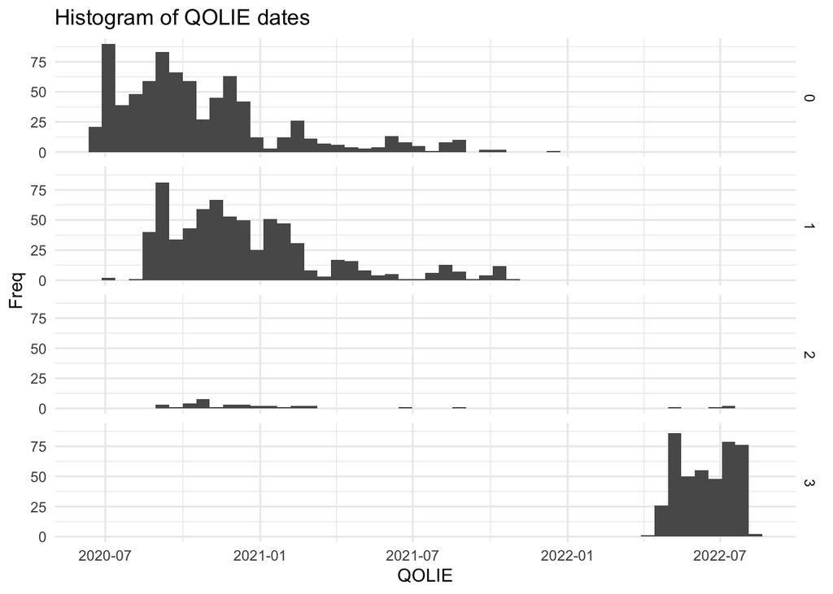

#### Complete Rate of the instruments

Complete Rates of QOLIE

| complete_rate | n | pct |
| --- | --- | --- |
| **EUC** |  |  |
| 100% | 654 | 68.6% |
| 90% - 99% | 212 | 22.2% |
| 80% - 89% | 63 | 6.6% |
| below 80% | 25 | 2.6% |
| **TSC** |  |  |
| 100% | 727 | 73.9% |
| 90% - 99% | 192 | 19.5% |
| 80% - 89% | 59 | 6.0% |
| below 80% | 6 | 0.6% |

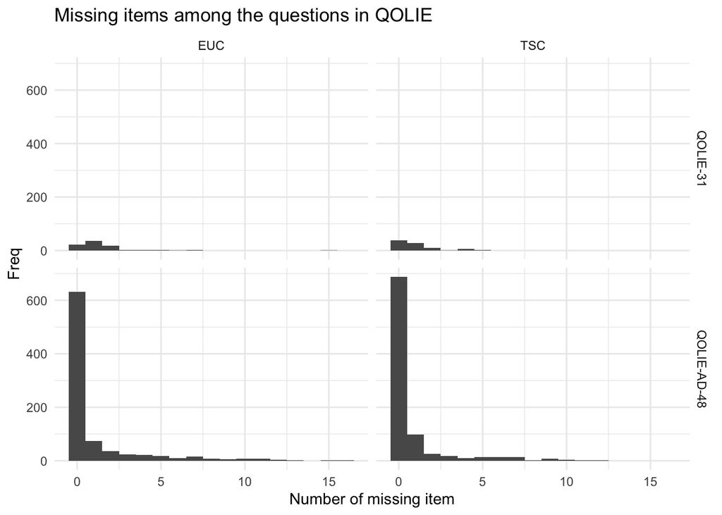

### Demographic of QOLIE users

#### Gender

| study_arm | gender | n | pct |
| --- | --- | --- | --- |
| EUC | Female | 153 | 36% |
| EUC | Male | 270 | 64% |
| TSC | Female | 152 | 35% |
| TSC | Male | 282 | 65% |

#### City

| study_arm | city | n | pct |
| --- | --- | --- | --- |
| EUC | Kaduna | 106 | 25.1% |
| EUC | Kano | 194 | 45.9% |
| EUC | Zaria | 123 | 29.1% |
| TSC | Kaduna | 100 | 23.0% |
| TSC | Kano | 219 | 50.5% |
| TSC | Zaria | 115 | 26.5% |

#### Age and Age eligibility

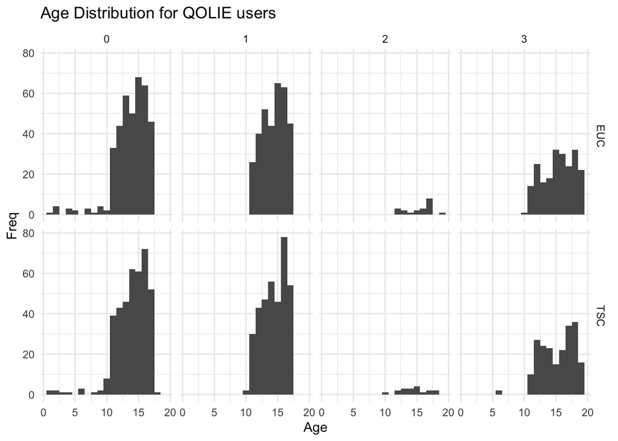

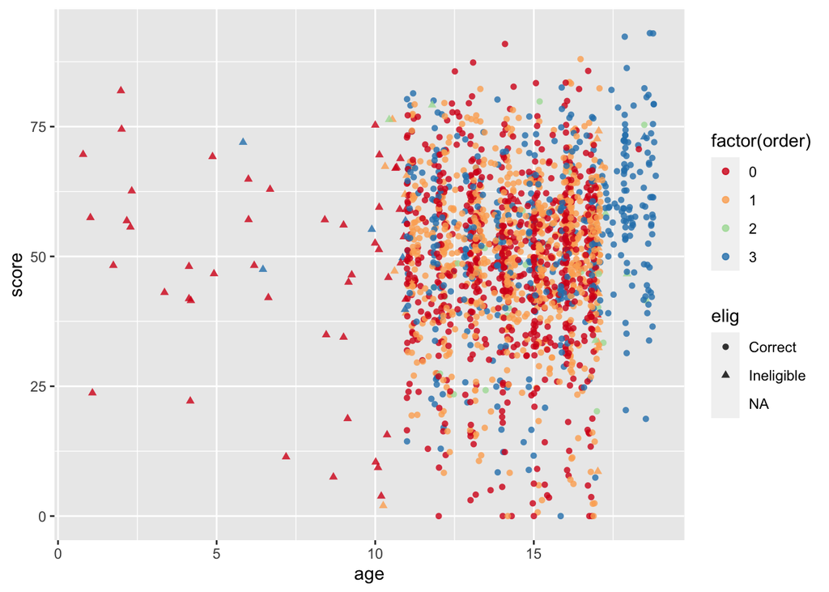

### Distribution of QOLIE Scores

QOLIE records by order

| order | n_records | pct_by_arm | mean_score | sd_score |
| --- | --- | --- | --- | --- |
| **EUC** |  |  |  |  |
| 0 | 384 | 40.3% | 48.64355 | 16.26517 |
| 1 | 335 | 35.1% | 50.18388 | 14.49982 |
| 2 | 21 | 2.2% | 45.49926 | 14.13036 |
| 3 | 214 | 22.4% | 52.78889 | 15.95609 |
| **TSC** |  |  |  |  |
| 0 | 397 | 40.3% | 48.50516 | 15.90460 |
| 1 | 357 | 36.3% | 49.37817 | 15.14167 |
| 2 | 21 | 2.1% | 53.18548 | 13.45470 |
| 3 | 209 | 21.2% | 55.79304 | 14.94166 |

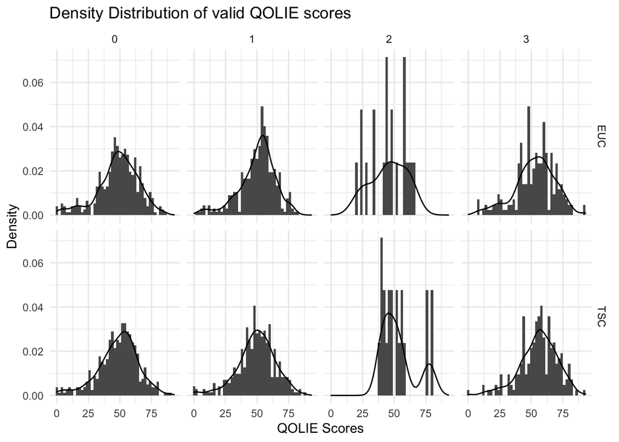

### Exploratory Hypothesis Testing

Because there are not enough samples for order == 2 which also includes some noises, I excluded the 2th order in the analysis. The inclusion criteria is: participants with at least 0th(the regarded “first”) and 3th(the regarded “last”) QOLIE records.

```
##
##  Two Sample t-test
##
## data:  score by factor(study_arm)
## t = -0.27968, df = 1022, p-value = 0.7798
## alternative hypothesis: true difference in means between group EUC and group TSC is not equal to 0
## 95 percent confidence interval:
##  -2.279052  1.710444
## sample estimates:
## mean in group EUC mean in group TSC
##          50.40689          50.69120
```

There’s no difference between 2 arms among all times.

The *study arm*, *order*, *gender*, and *city* variables are all categorical variables(like dummy variables) without numeric meaning, so we use factor here. *Age* is numeric.

```
##
## Call:
## lm(formula = score ~ factor(study_arm) * factor(order), data = qinfo)
##
## Residuals:
##     Min      1Q  Median      3Q     Max
## -55.935  -8.756   1.735  10.780  43.710
##
## Coefficients:
##                                     Estimate Std. Error t value Pr(>|t|)
## (Intercept)                          48.6763     1.2127  40.139   <2e-16 ***
## factor(study_arm)TSC                 -1.4699     1.7225  -0.853   0.3937
## factor(order)1                        1.8518     1.7408   1.064   0.2877
## factor(order)3                        3.3471     1.7150   1.952   0.0513 .
## factor(study_arm)TSC:factor(order)1  -0.2004     2.4671  -0.081   0.9353
## factor(study_arm)TSC:factor(order)3   5.3814     2.4359   2.209   0.0274 *
## ---
## Signif. codes:  0 '***' 0.001 '**' 0.01 '*' 0.05 '.' 0.1 ' ' 1
##
## Residual standard error: 16.04 on 1018 degrees of freedom
## Multiple R-squared:  0.03098,    Adjusted R-squared:  0.02623
## F-statistic:  6.51 on 5 and 1018 DF,  p-value: 5.707e-06
```

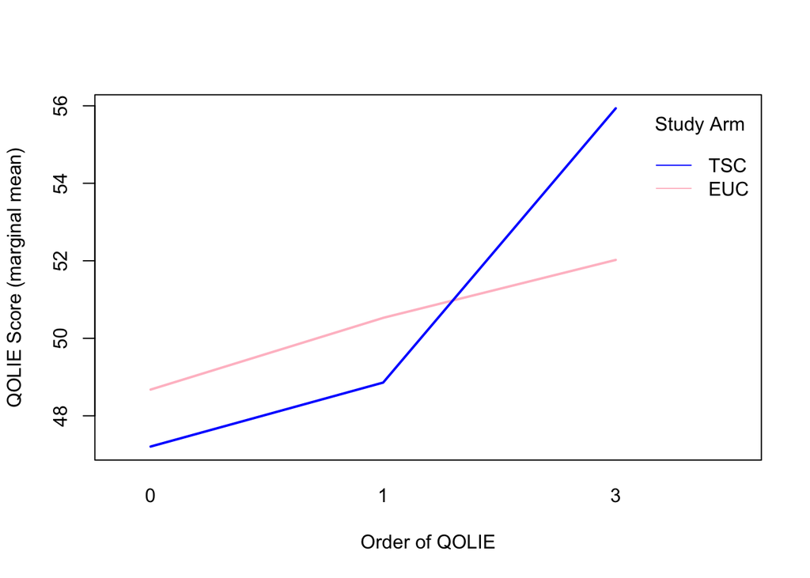

When trying to explain the group difference among the times and the arms,

Although the main effect of Treatment is even unsignificantly negative (as the total mean of EUC and TSC is so close), **which may caused by the group difference when sampling**,

the main effect of order is marginally(with p 0.05- 0.1) significantly positive – as time goes by (**may caused by more treatment, changes in life, age grows**), the QOLIE score improves;

the interaction of order and arm (TSC over EUC, order 3rd over order 0th) is significantly positive.

```
##
## Call:
## lm(formula = score ~ factor(study_arm) * factor(order) + age,
##     data = qinfo)
##
## Residuals:
##     Min      1Q  Median      3Q     Max
## -55.696  -8.587   1.678   9.880  43.836
##
## Coefficients:
##                                     Estimate Std. Error t value Pr(>|t|)
## (Intercept)                         29.34550    3.86423   7.594 7.00e-14 ***
## factor(study_arm)TSC                -1.44701    1.70034  -0.851   0.3950
## factor(order)1                       1.52686    1.71954   0.888   0.3748
## factor(order)3                       0.85438    1.75801   0.486   0.6271
## age                                  1.36126    0.25873   5.261 1.74e-07 ***
## factor(study_arm)TSC:factor(order)1 -0.09604    2.43544  -0.039   0.9686
## factor(study_arm)TSC:factor(order)3  5.37127    2.40464   2.234   0.0257 *
## ---
## Signif. codes:  0 '***' 0.001 '**' 0.01 '*' 0.05 '.' 0.1 ' ' 1
##
## Residual standard error: 15.84 on 1017 degrees of freedom
## Multiple R-squared:  0.05666,    Adjusted R-squared:  0.0511
## F-statistic: 10.18 on 6 and 1017 DF,  p-value: 5.856e-11
```

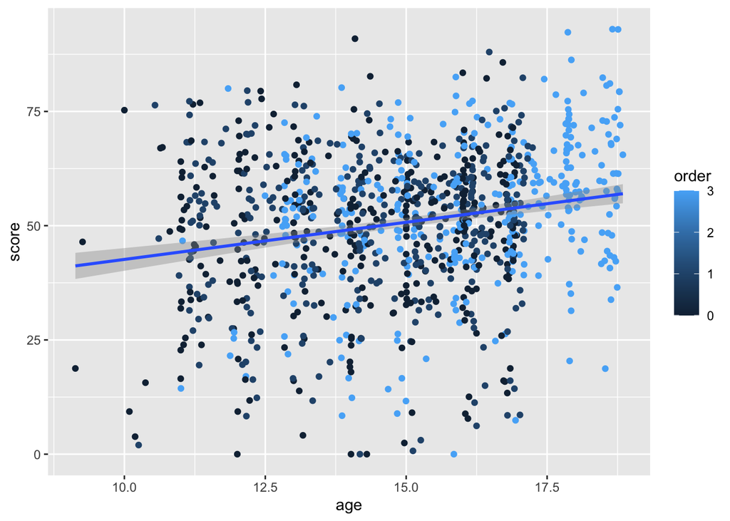

**Age plays a role over time** – the order is no longer have a mariginal significance.

But **the interaction still works**.

```
##
## Call:
## lm(formula = score ~ factor(study_arm) * factor(order) + factor(gender),
##     data = qinfo)
##
## Residuals:
##     Min      1Q  Median      3Q     Max
## -55.890  -8.711   1.758  10.817  43.635
##
## Coefficients:
##                                     Estimate Std. Error t value Pr(>|t|)
## (Intercept)                          48.7511     1.3741  35.479   <2e-16 ***
## factor(study_arm)TSC                 -1.4693     1.7233  -0.853   0.3941
## factor(order)1                        1.8505     1.7417   1.062   0.2883
## factor(order)3                        3.3471     1.7158   1.951   0.0514 .
## factor(gender)2                      -0.1201     1.0356  -0.116   0.9077
## factor(study_arm)TSC:factor(order)1  -0.1988     2.4683  -0.081   0.9358
## factor(study_arm)TSC:factor(order)3   5.3814     2.4371   2.208   0.0275 *
## ---
## Signif. codes:  0 '***' 0.001 '**' 0.01 '*' 0.05 '.' 0.1 ' ' 1
##
## Residual standard error: 16.05 on 1017 degrees of freedom
## Multiple R-squared:  0.031,  Adjusted R-squared:  0.02528
## F-statistic: 5.422 on 6 and 1017 DF,  p-value: 1.571e-05
```

**Gender plays no role.**

```
##
## Call:
## lm(formula = score ~ factor(study_arm) * factor(order) + factor(city),
##     data = qinfo)
##
## Residuals:
##     Min      1Q  Median      3Q     Max
## -50.615  -9.239   1.246  10.392  49.030
##
## Coefficients:
##                                     Estimate Std. Error t value Pr(>|t|)
## (Intercept)                         50.15158    1.68672  29.733  < 2e-16 ***
## factor(study_arm)TSC                -1.98101    1.66897  -1.187   0.2355
## factor(order)1                       1.59842    1.68440   0.949   0.3429
## factor(order)3                       3.34707    1.65918   2.017   0.0439 *
## factor(city)Kano                     2.55588    1.50749   1.695   0.0903 .
## factor(city)Zaria                   -6.28373    1.54575  -4.065 5.17e-05 ***
## factor(study_arm)TSC:factor(order)1 -0.02747    2.38685  -0.012   0.9908
## factor(study_arm)TSC:factor(order)3  5.38145    2.35665   2.284   0.0226 *
## ---
## Signif. codes:  0 '***' 0.001 '**' 0.01 '*' 0.05 '.' 0.1 ' ' 1
##
## Residual standard error: 15.52 on 1016 degrees of freedom
## Multiple R-squared:  0.09483,    Adjusted R-squared:  0.08859
## F-statistic: 15.21 on 7 and 1016 DF,  p-value: < 2.2e-16
```

**City plays a role for Zaria has smaller score compared to Keduna.**

## VAS

### Inclusion Criteria

1. if the *missed_fu* is like “no” or “on time”, include no matter any missing.
2. if the *missed_fu* is **NA** or “Visit Done”, inclusion depends on whether they filled all of *follow_up_care_form_complete*, *confirmseize*, *weight_fu_v2*, *seizeclass*.
3. if the *missed_fu* answers something else, exclude.

### Demographic

Gender in 2 arms

| study_arm | gender | n | pct |
| --- | --- | --- | --- |
| EUC | Female | 315 | 36% |
| EUC | Male | 567 | 64% |
| TSC | Female | 310 | 36% |
| TSC | Male | 561 | 64% |

City in 2 arms

| study_arm | city | n | pct |
| --- | --- | --- | --- |
| EUC | Kaduna | 206 | 23.4% |
| EUC | Kano | 439 | 49.8% |
| EUC | Zaria | 237 | 26.9% |
| TSC | Kaduna | 226 | 25.9% |
| TSC | Kano | 433 | 49.7% |
| TSC | Zaria | 212 | 24.3% |

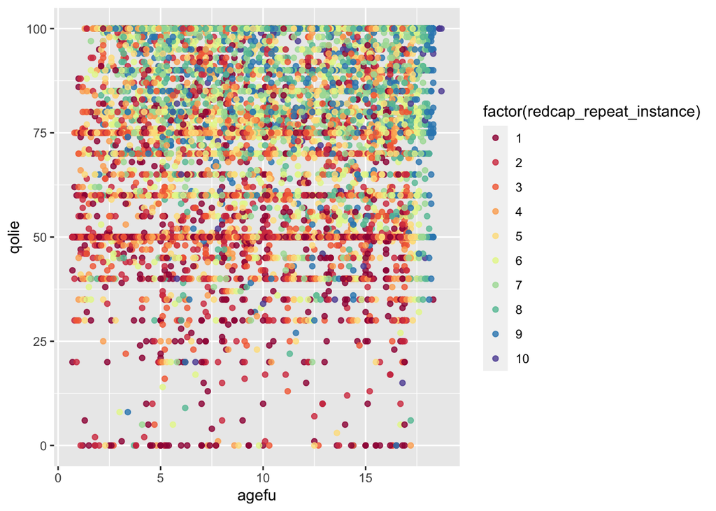

### Analysis of VAS over time

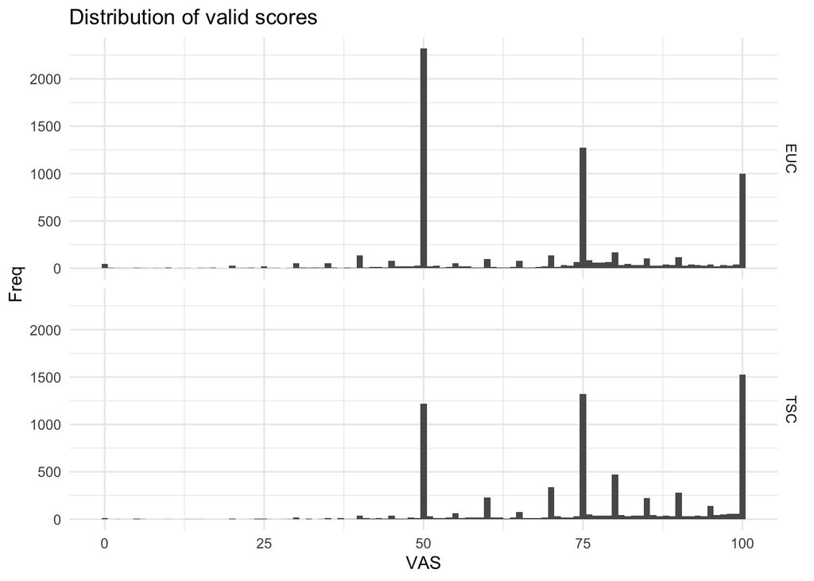

```
##
## Call:
## lm(formula = qolie ~ factor(study_arm) * factor(redcap_repeat_instance),
##     data = fcf_c)
##
## Residuals:
##     Min      1Q  Median      3Q     Max
## -81.577 -11.198  -0.459  12.423  48.000
##
## Coefficients:
##                                                       Estimate Std. Error
## (Intercept)                                            52.0000     0.6049
## factor(study_arm)TSC                                    6.6882     0.8527
## factor(redcap_repeat_instance)2                         3.0370     0.8594
## factor(redcap_repeat_instance)3                         7.6165     0.8630
## factor(redcap_repeat_instance)4                        11.3675     0.8677
## factor(redcap_repeat_instance)5                        15.5465     0.8730
## factor(redcap_repeat_instance)6                        19.9750     0.8742
## factor(redcap_repeat_instance)7                        23.4587     0.8803
## factor(redcap_repeat_instance)8                        27.9259     0.8835
## factor(redcap_repeat_instance)9                        27.3710     0.8995
## factor(redcap_repeat_instance)10                       26.5466     1.0719
## factor(study_arm)TSC:factor(redcap_repeat_instance)2    3.6945     1.2150
## factor(study_arm)TSC:factor(redcap_repeat_instance)3    2.6103     1.2251
## factor(study_arm)TSC:factor(redcap_repeat_instance)4    3.3098     1.2276
## factor(study_arm)TSC:factor(redcap_repeat_instance)5    1.8665     1.2330
## factor(study_arm)TSC:factor(redcap_repeat_instance)6    1.5350     1.2326
## factor(study_arm)TSC:factor(redcap_repeat_instance)7    1.2126     1.2351
## factor(study_arm)TSC:factor(redcap_repeat_instance)8    0.9629     1.2450
## factor(study_arm)TSC:factor(redcap_repeat_instance)9    2.4023     1.2657
## factor(study_arm)TSC:factor(redcap_repeat_instance)10   6.2500     1.5306
##                                                       t value Pr(>|t|)
## (Intercept)                                            85.962  < 2e-16 ***
## factor(study_arm)TSC                                    7.844 4.67e-15 ***
## factor(redcap_repeat_instance)2                         3.534 0.000411 ***
## factor(redcap_repeat_instance)3                         8.826  < 2e-16 ***
## factor(redcap_repeat_instance)4                        13.100  < 2e-16 ***
## factor(redcap_repeat_instance)5                        17.809  < 2e-16 ***
## factor(redcap_repeat_instance)6                        22.851  < 2e-16 ***
## factor(redcap_repeat_instance)7                        26.649  < 2e-16 ***
## factor(redcap_repeat_instance)8                        31.609  < 2e-16 ***
## factor(redcap_repeat_instance)9                        30.429  < 2e-16 ***
## factor(redcap_repeat_instance)10                       24.766  < 2e-16 ***
## factor(study_arm)TSC:factor(redcap_repeat_instance)2    3.041 0.002363 **
## factor(study_arm)TSC:factor(redcap_repeat_instance)3    2.131 0.033133 *
## factor(study_arm)TSC:factor(redcap_repeat_instance)4    2.696 0.007025 **
## factor(study_arm)TSC:factor(redcap_repeat_instance)5    1.514 0.130113
## factor(study_arm)TSC:factor(redcap_repeat_instance)6    1.245 0.213023
## factor(study_arm)TSC:factor(redcap_repeat_instance)7    0.982 0.326220
## factor(study_arm)TSC:factor(redcap_repeat_instance)8    0.773 0.439288
## factor(study_arm)TSC:factor(redcap_repeat_instance)9    1.898 0.057718 .
## factor(study_arm)TSC:factor(redcap_repeat_instance)10   4.083 4.46e-05 ***
## ---
## Signif. codes:  0 '***' 0.001 '**' 0.01 '*' 0.05 '.' 0.1 ' ' 1
##
## Residual standard error: 17.39 on 14535 degrees of freedom
##   (37 observations deleted due to missingness)
## Multiple R-squared:  0.2825, Adjusted R-squared:  0.2816
## F-statistic: 301.3 on 19 and 14535 DF,  p-value: < 2.2e-16
```

```
##
## Call:
## lm(formula = qolie ~ factor(study_arm) * factor(redcap_repeat_instance) +
##     agefu, data = fcf_c)
##
## Residuals:
##    Min     1Q Median     3Q    Max
## -81.98 -11.43  -0.79  12.19  48.31
##
## Coefficients:
##                                                       Estimate Std. Error
## (Intercept)                                           51.38349    0.67671
## factor(study_arm)TSC                                   6.66531    0.85303
## factor(redcap_repeat_instance)2                        3.03182    0.85999
## factor(redcap_repeat_instance)3                        7.61325    0.86354
## factor(redcap_repeat_instance)4                       11.35918    0.86835
## factor(redcap_repeat_instance)5                       15.51142    0.87343
## factor(redcap_repeat_instance)6                       19.90027    0.87634
## factor(redcap_repeat_instance)7                       23.33783    0.89040
## factor(redcap_repeat_instance)8                       27.83915    0.89182
## factor(redcap_repeat_instance)9                       27.20015    0.91576
## factor(redcap_repeat_instance)10                      22.17748    2.27500
## agefu                                                  0.06501    0.03194
## factor(study_arm)TSC:factor(redcap_repeat_instance)2   3.69686    1.21557
## factor(study_arm)TSC:factor(redcap_repeat_instance)3   2.60008    1.22573
## factor(study_arm)TSC:factor(redcap_repeat_instance)4   3.29207    1.22827
## factor(study_arm)TSC:factor(redcap_repeat_instance)5   1.86861    1.23345
## factor(study_arm)TSC:factor(redcap_repeat_instance)6   1.49799    1.23516
## factor(study_arm)TSC:factor(redcap_repeat_instance)7   1.03871    1.24945
## factor(study_arm)TSC:factor(redcap_repeat_instance)8   0.97562    1.25263
## factor(study_arm)TSC:factor(redcap_repeat_instance)9   2.51229    1.28666
## factor(study_arm)TSC:factor(redcap_repeat_instance)10 12.35307    2.95747
##                                                       t value Pr(>|t|)
## (Intercept)                                            75.931  < 2e-16 ***
## factor(study_arm)TSC                                    7.814 5.96e-15 ***
## factor(redcap_repeat_instance)2                         3.525 0.000424 ***
## factor(redcap_repeat_instance)3                         8.816  < 2e-16 ***
## factor(redcap_repeat_instance)4                        13.081  < 2e-16 ***
## factor(redcap_repeat_instance)5                        17.759  < 2e-16 ***
## factor(redcap_repeat_instance)6                        22.708  < 2e-16 ***
## factor(redcap_repeat_instance)7                        26.211  < 2e-16 ***
## factor(redcap_repeat_instance)8                        31.216  < 2e-16 ***
## factor(redcap_repeat_instance)9                        29.702  < 2e-16 ***
## factor(redcap_repeat_instance)10                        9.748  < 2e-16 ***
## agefu                                                   2.035 0.041851 *
## factor(study_arm)TSC:factor(redcap_repeat_instance)2    3.041 0.002360 **
## factor(study_arm)TSC:factor(redcap_repeat_instance)3    2.121 0.033918 *
## factor(study_arm)TSC:factor(redcap_repeat_instance)4    2.680 0.007365 **
## factor(study_arm)TSC:factor(redcap_repeat_instance)5    1.515 0.129809
## factor(study_arm)TSC:factor(redcap_repeat_instance)6    1.213 0.225231
## factor(study_arm)TSC:factor(redcap_repeat_instance)7    0.831 0.405802
## factor(study_arm)TSC:factor(redcap_repeat_instance)8    0.779 0.436078
## factor(study_arm)TSC:factor(redcap_repeat_instance)9    1.953 0.050891 .
## factor(study_arm)TSC:factor(redcap_repeat_instance)10   4.177 2.97e-05 ***
## ---
## Signif. codes:  0 '***' 0.001 '**' 0.01 '*' 0.05 '.' 0.1 ' ' 1
##
## Residual standard error: 17.39 on 13757 degrees of freedom
##   (814 observations deleted due to missingness)
## Multiple R-squared:  0.2754, Adjusted R-squared:  0.2743
## F-statistic: 261.4 on 20 and 13757 DF,  p-value: < 2.2e-16
```

```
## age plays a role but the factors still have siginificant effects.
```

```
##
## Call:
## lm(formula = qolie ~ factor(study_arm) * factor(redcap_repeat_instance) +
##     factor(gender), data = fcf_c)
##
## Residuals:
##     Min      1Q  Median      3Q     Max
## -81.562 -11.205  -0.487  12.394  48.016
##
## Coefficients:
##                                                       Estimate Std. Error
## (Intercept)                                           52.02882    0.63532
## factor(study_arm)TSC                                   6.68817    0.85269
## factor(redcap_repeat_instance)2                        3.03692    0.85946
## factor(redcap_repeat_instance)3                        7.61599    0.86299
## factor(redcap_repeat_instance)4                       11.36714    0.86775
## factor(redcap_repeat_instance)5                       15.54645    0.87299
## factor(redcap_repeat_instance)6                       19.97475    0.87419
## factor(redcap_repeat_instance)7                       23.45837    0.88033
## factor(redcap_repeat_instance)8                       27.92547    0.88352
## factor(redcap_repeat_instance)9                       27.37057    0.89954
## factor(redcap_repeat_instance)10                      26.54489    1.07200
## factor(gender)2                                       -0.04467    0.30085
## factor(study_arm)TSC:factor(redcap_repeat_instance)2   3.69464    1.21500
## factor(study_arm)TSC:factor(redcap_repeat_instance)3   2.61061    1.22516
## factor(study_arm)TSC:factor(redcap_repeat_instance)4   3.30986    1.22768
## factor(study_arm)TSC:factor(redcap_repeat_instance)5   1.86698    1.23307
## factor(study_arm)TSC:factor(redcap_repeat_instance)6   1.53521    1.23266
## factor(study_arm)TSC:factor(redcap_repeat_instance)7   1.21307    1.23517
## factor(study_arm)TSC:factor(redcap_repeat_instance)8   0.96402    1.24509
## factor(study_arm)TSC:factor(redcap_repeat_instance)9   2.40316    1.26576
## factor(study_arm)TSC:factor(redcap_repeat_instance)10  6.25263    1.53075
##                                                       t value Pr(>|t|)
## (Intercept)                                            81.894  < 2e-16 ***
## factor(study_arm)TSC                                    7.844 4.68e-15 ***
## factor(redcap_repeat_instance)2                         3.534 0.000411 ***
## factor(redcap_repeat_instance)3                         8.825  < 2e-16 ***
## factor(redcap_repeat_instance)4                        13.100  < 2e-16 ***
## factor(redcap_repeat_instance)5                        17.808  < 2e-16 ***
## factor(redcap_repeat_instance)6                        22.850  < 2e-16 ***
## factor(redcap_repeat_instance)7                        26.647  < 2e-16 ***
## factor(redcap_repeat_instance)8                        31.607  < 2e-16 ***
## factor(redcap_repeat_instance)9                        30.427  < 2e-16 ***
## factor(redcap_repeat_instance)10                       24.762  < 2e-16 ***
## factor(gender)2                                        -0.148 0.881964
## factor(study_arm)TSC:factor(redcap_repeat_instance)2    3.041 0.002363 **
## factor(study_arm)TSC:factor(redcap_repeat_instance)3    2.131 0.033119 *
## factor(study_arm)TSC:factor(redcap_repeat_instance)4    2.696 0.007025 **
## factor(study_arm)TSC:factor(redcap_repeat_instance)5    1.514 0.130026
## factor(study_arm)TSC:factor(redcap_repeat_instance)6    1.245 0.212987
## factor(study_arm)TSC:factor(redcap_repeat_instance)7    0.982 0.326065
## factor(study_arm)TSC:factor(redcap_repeat_instance)8    0.774 0.438792
## factor(study_arm)TSC:factor(redcap_repeat_instance)9    1.899 0.057639 .
## factor(study_arm)TSC:factor(redcap_repeat_instance)10   4.085 4.44e-05 ***
## ---
## Signif. codes:  0 '***' 0.001 '**' 0.01 '*' 0.05 '.' 0.1 ' ' 1
##
## Residual standard error: 17.39 on 14534 degrees of freedom
##   (37 observations deleted due to missingness)
## Multiple R-squared:  0.2825, Adjusted R-squared:  0.2815
## F-statistic: 286.2 on 20 and 14534 DF,  p-value: < 2.2e-16
```

```
## There is no difference between the genders.
```

```
##
## Call:
## lm(formula = qolie ~ factor(study_arm) * factor(redcap_repeat_instance) +
##     factor(city), data = fcf_c)
##
## Residuals:
##     Min      1Q  Median      3Q     Max
## -80.420 -12.066  -0.655  12.644  50.264
##
## Coefficients:
##                                                       Estimate Std. Error
## (Intercept)                                            56.8989     0.6511
## factor(study_arm)TSC                                    6.4863     0.8422
## factor(redcap_repeat_instance)2                         3.0426     0.8488
## factor(redcap_repeat_instance)3                         7.5872     0.8523
## factor(redcap_repeat_instance)4                        11.3281     0.8570
## factor(redcap_repeat_instance)5                        15.5094     0.8622
## factor(redcap_repeat_instance)6                        20.0250     0.8634
## factor(redcap_repeat_instance)7                        23.5411     0.8694
## factor(redcap_repeat_instance)8                        28.0295     0.8726
## factor(redcap_repeat_instance)9                        27.5077     0.8884
## factor(redcap_repeat_instance)10                       27.2176     1.0592
## factor(city)Kano                                       -5.9297     0.3558
## factor(city)Zaria                                      -7.1628     0.4072
## factor(study_arm)TSC:factor(redcap_repeat_instance)2    3.6718     1.2000
## factor(study_arm)TSC:factor(redcap_repeat_instance)3    2.6125     1.2100
## factor(study_arm)TSC:factor(redcap_repeat_instance)4    3.2827     1.2125
## factor(study_arm)TSC:factor(redcap_repeat_instance)5    1.8264     1.2178
## factor(study_arm)TSC:factor(redcap_repeat_instance)6    1.5195     1.2174
## factor(study_arm)TSC:factor(redcap_repeat_instance)7    1.1299     1.2199
## factor(study_arm)TSC:factor(redcap_repeat_instance)8    0.9349     1.2297
## factor(study_arm)TSC:factor(redcap_repeat_instance)9    2.3932     1.2501
## factor(study_arm)TSC:factor(redcap_repeat_instance)10   6.5441     1.5119
##                                                       t value Pr(>|t|)
## (Intercept)                                            87.388  < 2e-16 ***
## factor(study_arm)TSC                                    7.701 1.43e-14 ***
## factor(redcap_repeat_instance)2                         3.585 0.000339 ***
## factor(redcap_repeat_instance)3                         8.902  < 2e-16 ***
## factor(redcap_repeat_instance)4                        13.218  < 2e-16 ***
## factor(redcap_repeat_instance)5                        17.988  < 2e-16 ***
```

[output cut: 8 more lines]

```
## factor(study_arm)TSC:factor(redcap_repeat_instance)3    2.159 0.030857 *
## factor(study_arm)TSC:factor(redcap_repeat_instance)4    2.707 0.006789 **
## factor(study_arm)TSC:factor(redcap_repeat_instance)5    1.500 0.133706
## factor(study_arm)TSC:factor(redcap_repeat_instance)6    1.248 0.211997
## factor(study_arm)TSC:factor(redcap_repeat_instance)7    0.926 0.354323
## factor(study_arm)TSC:factor(redcap_repeat_instance)8    0.760 0.447076
## factor(study_arm)TSC:factor(redcap_repeat_instance)9    1.914 0.055581 .
## factor(study_arm)TSC:factor(redcap_repeat_instance)10   4.329 1.51e-05 ***
## ---
## Signif. codes:  0 '***' 0.001 '**' 0.01 '*' 0.05 '.' 0.1 ' ' 1
##
## Residual standard error: 17.17 on 14533 degrees of freedom
##   (37 observations deleted due to missingness)
## Multiple R-squared:  0.3002, Adjusted R-squared:  0.2992
## F-statistic: 296.9 on 21 and 14533 DF,  p-value: < 2.2e-16
```

```
## As for the cities, Keduna > Kano > Zaria
```

# Questions for Aim 3 Meeting

## Content of Aim 3 in the protocol

**Determine the cost-effectiveness of the task-shifted epilepsy care intervention.**

Direct costs of the intervention and EUC will include personnel costs (including CHEW epilepsy training) and expenses for diagnostic (EEG, brain imaging) and laboratory tests and anti-epileptic drugs.

Indirect costs will include travel time and time away from work for parents/guardians and change in school attendance for patients.

Cost-effectiveness will be expressed as US dollars per disability adjusted life year (DALY) averted.

## Progress of our work

Half-way to find the effectiveness of TSC.

## Questions

1. We have collected both VAS scores over the 10 follow up visits and Qolie scores from the Screening and follow up visits. Which one should we use for the calculation of effectiveness: just VAS, just Qolie, or mix them?
2. Is the age restriction necessary for data admission?
3. What is the timeline for Aim 3 research?